# On understanding and manipulating the hatching patterns of Diabrotica v. virgifera (Coleoptera: Chrysomelidae) eggs to improve the design of experiments

Extended analysis report

Dr. Mark Szalai and Szabolcs Toth

2021

# 1. Data wrangling

## 1.1. Import and clean the dataset

Get and set working directory. Drop accidental coercion of 3 invalid column from end of the .csv file. Remove empty rows from the end (NA for `Case`) and remove the "filler" rows with no real data as `Date_check`: NA.

```r
#getwd()
#setwd()
datadiapause <- read.csv("Dvv_EggHatching_CleanedRawData_ZenodoSub.csv", header=T, na.strings=c("","NA"))
datadiapause <- datadiapause[,-c(31:33)]
datadiap <- datadiapause[!is.na(datadiapause$Case) & !is.na(datadiapause$Date_check),]
```

Eggs from laboratory reared CSE (not wild collected and reared!) later on proved to be low quality (ie. lack of hatching), thus removed form the analysis

```r
datadiap <- datadiap[!(datadiap$EggOrigin == "CSE" &
                           datadiap$Field_Lab_eggs == "Lab"),]
```

## 1.2. Creating categories for different diapause length

Please note that the category names will be different in the data visualization part. Separate CSE eggs which are spent 0 month in diapuse from Non-diapause eggs which is also spent 0 months in diapause.~ 3 months intervals, expect special cases.

```r
categories <-
  c("ND","0","0.5 to 1.5m","2 to 4m","5 to 7m","8 to 10m",
    "11 to 13m", "14 to 16m", "17m or more")
ideal <- "8 to 10m"
MonCatBreaks <- c(0, 0.1, 1.6, 4.5, 7.5, 10.5, 13.5, 16, Inf)

datadiap$DiapMonCat <-     #make categories according to the diap length
  as.character(cut(datadiap$DiapMonths,
      breaks = MonCatBreaks,
      labels = categories[-1], #minus ND!
      right = FALSE))

datadiap$DiapMonCat <- ifelse (datadiap$EggOrigin == "ND",   # add NDs to separate one (special case of 0 months in diap.)
                                     "ND", datadiap$DiapMonCat)

datadiap$DiapMonCat <- ordered(datadiap$DiapMonCat,
                                   levels = categories)
```

## 1.3. Create "traytable" as a helper table

```r
traytable <- unique(dplyr::select(datadiap,
                                  ExpSeries : TempC, DiapMonCat, -LaidUntil))
```

# 2. Data aggregation and selection

## 2.1. Calculating hatch ratio, hatching -start, -end, -duration and -peak

1. hatch start: the first day (min of Days_aft_diastop) when Larvae_hatched above 0
2. hatch end: the last day (max of Days_aft_diastop) when Larvae_hatched above 0
3. hatch duration: hatchend - hatchstart + 1
4. hatch peak: the first(!) day (Days_aft_diastop) when Larvae_hatched is the max (BUT if no hatch at all, it should be NA, not 0)
5. hatch ratio: total hatch number per alive eggs (in %)
6. hatchsum = sum(Larvae_hatched)

Use of the helper traytable and create hatchtable, thus Every CASE_TRAY_dish_No in one row.

```r
hatchtable <-
  summarise(group_by(datadiap, CASE_Tray_dish_No),
            hatchstart = Days_aft_diastop[min(which(Larvae_hatched >= 1))],
            hatchend = Days_aft_diastop[max(which(Larvae_hatched >= 1))],
            hatchduration = hatchend - hatchstart + 1,
            hatchpeak = ifelse(all(Larvae_hatched == 0),
                               NA, Days_aft_diastop[which.max(Larvae_hatched)]),
            hatchratio = 100 * sum(Larvae_hatched) / mean(EggsAlive),
            hatchsum = sum(Larvae_hatched))

hatchtable <- merge(hatchtable, traytable)
```

## 2.2. Trays with very low number of hatched larvae

[output not shown]

## 2.3. Final data tables

Re-naming hatchtable to hatchtable0

```r
hatchtable0 <- hatchtable

identical(hatchtable0, hatchtable)
```

```
## [1] TRUE
```

## 2.4. Dealing with low hatched larvae numbers

For further analysis it has been decided for petri dishes (column: CASE_tray_dish_No) which led to lower than 6 living larvae are not involved anymore in data visualization and mean calculations in case of: hatchstart, hatchend, hatchduration. Still involved in hatchingpeak and hatching ratio calculations.

```r
hatchtable$hatchstart[hatchtable$hatchsum < 6] <- NA
hatchtable$hatchend[hatchtable$hatchsum < 6] <- NA
hatchtable$hatchduration[hatchtable$hatchsum < 6] <- NA
```

## 2.5. ND data visualization at the aggregated dish level

ND eggs were use as a reference point thus there data aggregating 4 petri dish data from the two original main dishes (Column: DishNo) was done for data visualization purposes.

```r
hatchtable4 <- summarise_at(group_by(hatchtable,
                                     DishNo, Exp_ID, TempC),
                            vars(starts_with("hatch")),
                            mean, na.rm = TRUE)
hatchtable4 <- merge(hatchtable4,
                     unique(dplyr::select(traytable,
                                          -(CASE_Tray_dish_No : EggsDead))))

# to have single value for each temperature level for ND
hatchtable4ND <- summarise_at(group_by(filter(hatchtable, EggOrigin == "ND"),
                                         TempC, DiapMonths),
                            vars(starts_with("hatch")),
                            mean, na.rm = TRUE)
```

# 3. Data visualization and statistical analysis

## 3.1. Outsourcing repetitive elements for exploratory data visialization

### 3.1.1 Style elements for the exploratory graphs

```r
#general x scale for diap time spent in months
scalebreakx <- c(0,2,4,6,8,10,12,14,16,18,20,22,24,26,28)

#reusable style template

styleFigX = list(scale_x_continuous(breaks = scalebreakx),
             scale_color_manual(labels = c("  16 C戼㸰", "  20 C戼㸰", "  24 C戼㸰")), #C戼㸰 sometimes not visible
             scale_linetype_manual(values=c("solid", "twodash" ,"dotted")),
   theme(
         text = element_text(size = 34, family = "arial"),
         panel.background = element_rect(fill = NA),
         panel.grid.major = element_line(colour = "grey80"),
         axis.title.y = element_text(margin = margin(r = +20)),
         axis.title.x = element_text(margin = margin(t = +20)),
         panel.border = element_rect(color = "black", fill = NA, size = 1),
         axis.text.x = element_text(size = 28),
         legend.key.width = unit(1.5, "cm"),
         legend.key.height = unit(1, "cm")),
    labs(x ="Months spent in diapause",
         color = ""), #y-scale title is not formatted
   ylim(0,170))
```

### 3.1.2 Function for graphs creation for CSE and ND eggs visualization

Treylevelplot: calling it shows every petri dish as a point within the different incubation temperature regimes of the called diapause pattern variable. ND data overlayed as geom_point.

```r
treylevelplot <- function(y){
  yq <- enquo(y)
  ggplot(filter(hatchtable, EggOrigin == "CSE"),
         aes(DiapMonths, !!yq)) +
    geom_point(aes(shape = as.factor(TempC)), size = 4, position=position_jitter(width=.8))  +
    geom_smooth(aes(linetype = as.factor(TempC)),size = 2.2 ,se = FALSE, color = "red") +
    styleFigX
 }

NDpoint <- geom_point(data = hatchtable4ND,
                      shape = 18, size = 12, color = "blue", show.legend = FALSE) # blue, rhombus shape for ND points
```

## 3.2. Hatching start

### 3.2.1. Hatching start visualization

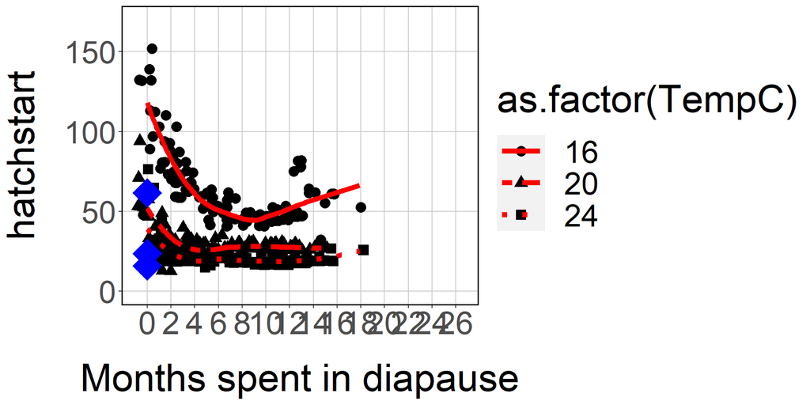

```r
treylevelplot(hatchstart) + NDpoint
```

### 3.2.2. Hatching start statistics

```r
#temperature categories as factors conversion

hatchtable$TempCf <- as.factor(hatchtable$TempC)
```

First part will be only focus on CSE eggs, thus ND eggs temporarily removed and created hatchtableNoND.

```r
hatchtableNoND <- hatchtable[hatchtable$EggOrigin == "CSE",]
```

The general response of the hatching start was affected by the the different time length spent in diapause and the different incubation temperatures.

```r
gamhs <- mgcv::gam(hatchstart ~ s(DiapMonths) + TempCf-1,
                   data = hatchtableNoND)

anova(gamhs)
```

```
##
## Family: gaussian
## Link function: identity
##
## Formula:
## hatchstart ~ s(DiapMonths) + TempCf - 1
##
## Parametric Terms:
##        df    F p-value
## TempCf  3 2282  <2e-16
##
## Approximate significance of smooth terms:
##                 edf Ref.df     F p-value
## s(DiapMonths) 7.873  8.676 47.83  <2e-16
```

```r
# plot(gamhs)
# mgcv::gam.check(gamhs)
```

Pairwise comparison of the used incubation temperatures the they are indeed differently affect the hatching start

```r
multgamhs <- glht(gamhs, linfct = c('TempCf16 - TempCf20 == 0',
                                    'TempCf16 - TempCf24 == 0',
                                    'TempCf20 - TempCf24 == 0'))
summary(multgamhs)
```

```
##
##   Simultaneous Tests for General Linear Hypotheses
##
## Fit: mgcv::gam(formula = hatchstart ~ s(DiapMonths) + TempCf - 1,
##     data = hatchtableNoND)
##
## Linear Hypotheses:
##                          Estimate Std. Error z value Pr(>|z|)
## TempCf16 - TempCf20 == 0   33.021      1.232  26.794   <1e-10 ***
## TempCf16 - TempCf24 == 0   41.450      1.232  33.644   <1e-10 ***
## TempCf20 - TempCf24 == 0    8.429      1.200   7.023   <1e-10 ***
## ---
## Signif. codes:  0 '***' 0.001 '**' 0.01 '*' 0.05 '.' 0.1 ' ' 1
## (Adjusted p values reported -- single-step method)
```

```r
confint(multgamhs)$confint
```

```
##                      Estimate       lwr      upr
## TempCf16 - TempCf20 33.021231 30.133115 35.90935
## TempCf16 - TempCf24 41.450174 38.562966 44.33738
## TempCf20 - TempCf24  8.428943  5.616182 11.24170
## attr(,"conf.level")
## [1] 0.95
## attr(,"calpha")
## [1] 2.343484
```

ModelDiap creation: A function created for the pairwise comparisons of the different length CSE categories within the corresponding incubation temperature (not between them!). 1. F statistics and compact letter display format between the categories. 2. Estimate, Std. Error, t-values and p-values above for all category comparisons.

```r
ModelDiap <- function(response, temperature){
  df <- hatchtable[hatchtable$TempC == temperature &
                     hatchtable$EggOrigin == "CSE",] #temporary dataframe: df created
  formula0 <- as.formula(paste(response, "~ DiapMonCat"))
  model0 <- lm(formula0, data = df)
  cat("F statistics", "\n")
  print(summary(model0)$fstatistic)
  multmodel <- glht(model0, linfct = mcp(DiapMonCat = "Tukey"))
  CLD <- cld(multmodel)
  cat("All pairwise comparisons, with compact letter display", "\n")
  print(CLD)
  print(summary(multmodel))
  cldDF <- data.frame(TempC = temperature,
                      DiapMonCat = names(CLD$mcletters$Letters),
                      cld = as.character(CLD$mcletters$Letters))
  names(cldDF)[3] <- paste0(response, "CLD")
  cldDF
}
```

First, for the 24C incubated CSE eggs

```r
hatchstart24cld <- ModelDiap("hatchstart", 24)
```

```
## F statistics
##    value    numdf    dendf
##  28.7306   7.0000 140.0000
## All pairwise comparisons, with compact letter display
##           0 0.5 to 1.5m     2 to 4m     5 to 7m    8 to 10m   11 to 13m
##         "c"         "b"         "a"         "a"         "a"         "a"
##   14 to 16m 17m or more
##        "ab"        "ab"
##
##   Simultaneous Tests for General Linear Hypotheses
##
## Multiple Comparisons of Means: Tukey Contrasts
##
##
## Fit: lm(formula = formula0, data = df)
##
## Linear Hypotheses:
##                                Estimate Std. Error t value Pr(>|t|)
## 0.5 to 1.5m - 0 == 0           -23.1333     2.5437  -9.095   <0.001 ***
## 2 to 4m - 0 == 0               -29.9030     2.3639 -12.650   <0.001 ***
## 5 to 7m - 0 == 0               -29.3273     2.3639 -12.406   <0.001 ***
## 8 to 10m - 0 == 0              -30.9929     2.3915 -12.960   <0.001 ***
## 11 to 13m - 0 == 0             -30.5200     2.4131 -12.648   <0.001 ***
## 14 to 16m - 0 == 0             -29.2250     2.8081 -10.407   <0.001 ***
## 17m or more - 0 == 0           -23.6000     5.3959  -4.374   <0.001 ***
## 2 to 4m - 0.5 to 1.5m == 0      -6.7697     1.5339  -4.413   <0.001 ***
## 5 to 7m - 0.5 to 1.5m == 0      -6.1939     1.5339  -4.038   0.0018 **
## 8 to 10m - 0.5 to 1.5m == 0     -7.8595     1.5761  -4.987   <0.001 ***
## 11 to 13m - 0.5 to 1.5m == 0    -7.3867     1.6087  -4.592   <0.001 ***
## 14 to 16m - 0.5 to 1.5m == 0    -6.0917     2.1565  -2.825   0.0823 .
## 17m or more - 0.5 to 1.5m == 0  -0.4667     5.0873  -0.092   1.0000
## 5 to 7m - 2 to 4m == 0           0.5758     1.2126   0.475   0.9997
## 8 to 10m - 2 to 4m == 0         -1.0898     1.2656  -0.861   0.9864
## 11 to 13m - 2 to 4m == 0        -0.6170     1.3061  -0.472   0.9997
## 14 to 16m - 2 to 4m == 0         0.6780     1.9412   0.349   1.0000
## 17m or more - 2 to 4m == 0       6.3030     4.9998   1.261   0.8963
## 8 to 10m - 5 to 7m == 0         -1.6656     1.2656  -1.316   0.8734
## 11 to 13m - 5 to 7m == 0        -1.1927     1.3061  -0.913   0.9809
## 14 to 16m - 5 to 7m == 0         0.1023     1.9412   0.053   1.0000
## 17m or more - 5 to 7m == 0       5.7273     4.9998   1.145   0.9350
## 11 to 13m - 8 to 10m == 0        0.4729     1.3554   0.349   1.0000
## 14 to 16m - 8 to 10m == 0        1.7679     1.9747   0.895   0.9830
## 17m or more - 8 to 10m == 0      7.3929     5.0130   1.475   0.7937
## 14 to 16m - 11 to 13m == 0       1.2950     2.0009   0.647   0.9976
## 17m or more - 11 to 13m == 0     6.9200     5.0233   1.378   0.8449
## 17m or more - 14 to 16m == 0     5.6250     5.2246   1.077   0.9528
## ---
## Signif. codes:  0 '***' 0.001 '**' 0.01 '*' 0.05 '.' 0.1 ' ' 1
## (Adjusted p values reported -- single-step method)
```

Second, for the lowest, 16C incubated CSE eggs

```r
hatchstart16cld <- ModelDiap("hatchstart", 16)
```

```
## F statistics
##     value     numdf     dendf
##  47.52645   7.00000 125.00000
## All pairwise comparisons, with compact letter display
##           0 0.5 to 1.5m     2 to 4m     5 to 7m    8 to 10m   11 to 13m
##         "e"         "d"         "c"        "ab"         "a"         "b"
##   14 to 16m 17m or more
##       "abc"       "abc"
##
##   Simultaneous Tests for General Linear Hypotheses
##
## Multiple Comparisons of Means: Tukey Contrasts
##
##
## Fit: lm(formula = formula0, data = df)
##
## Linear Hypotheses:
##                                Estimate Std. Error t value Pr(>|t|)
## 0.5 to 1.5m - 0 == 0            -29.143      5.933  -4.912  < 0.001 ***
## 2 to 4m - 0 == 0                -52.833      5.488  -9.627  < 0.001 ***
## 5 to 7m - 0 == 0                -70.935      5.574 -12.726  < 0.001 ***
## 8 to 10m - 0 == 0               -76.919      5.423 -14.184  < 0.001 ***
## 11 to 13m - 0 == 0              -66.370      5.574 -11.907  < 0.001 ***
## 14 to 16m - 0 == 0              -65.250      6.567  -9.937  < 0.001 ***
## 17m or more - 0 == 0            -69.500     13.133  -5.292  < 0.001 ***
## 2 to 4m - 0.5 to 1.5m == 0      -23.690      4.004  -5.916  < 0.001 ***
## 5 to 7m - 0.5 to 1.5m == 0      -41.792      4.122 -10.140  < 0.001 ***
## 8 to 10m - 0.5 to 1.5m == 0     -47.776      3.915 -12.203  < 0.001 ***
## 11 to 13m - 0.5 to 1.5m == 0    -37.227      4.122  -9.032  < 0.001 ***
## 14 to 16m - 0.5 to 1.5m == 0    -36.107      5.389  -6.700  < 0.001 ***
## 17m or more - 0.5 to 1.5m == 0  -40.357     12.586  -3.207  0.02955 *
## 5 to 7m - 2 to 4m == 0          -18.101      3.450  -5.247  < 0.001 ***
## 8 to 10m - 2 to 4m == 0         -24.086      3.201  -7.525  < 0.001 ***
## 11 to 13m - 2 to 4m == 0        -13.536      3.450  -3.923  0.00304 **
## 14 to 16m - 2 to 4m == 0        -12.417      4.894  -2.537  0.16753
## 17m or more - 2 to 4m == 0      -16.667     12.382  -1.346  0.86175
## 8 to 10m - 5 to 7m == 0          -5.985      3.346  -1.788  0.59513
## 11 to 13m - 5 to 7m == 0          4.565      3.585   1.273  0.89268
## 14 to 16m - 5 to 7m == 0          5.685      4.991   1.139  0.93778
## 17m or more - 5 to 7m == 0        1.435     12.420   0.116  1.00000
## 11 to 13m - 8 to 10m == 0        10.550      3.346   3.153  0.03470 *
## 14 to 16m - 8 to 10m == 0        11.669      4.822   2.420  0.21432
## 17m or more - 8 to 10m == 0       7.419     12.354   0.601  0.99855
## 14 to 16m - 11 to 13m == 0        1.120      4.991   0.224  1.00000
## 17m or more - 11 to 13m == 0     -3.130     12.420  -0.252  1.00000
## 17m or more - 14 to 16m == 0     -4.250     12.897  -0.330  0.99997
## ---
## Signif. codes:  0 '***' 0.001 '**' 0.01 '*' 0.05 '.' 0.1 ' ' 1
## (Adjusted p values reported -- single-step method)
```

Third, for the 20C incubated CSE eggs

```r
hatchstart20cld <-ModelDiap("hatchstart", 20)
```

```
## F statistics
##     value     numdf     dendf
##  35.98293   6.00000 140.00000
## All pairwise comparisons, with compact letter display
##           0 0.5 to 1.5m     2 to 4m     5 to 7m    8 to 10m   11 to 13m
##         "c"         "b"         "a"         "a"         "a"         "a"
##   14 to 16m
##         "a"
##
##   Simultaneous Tests for General Linear Hypotheses
##
## Multiple Comparisons of Means: Tukey Contrasts
##
##
## Fit: lm(formula = formula0, data = df)
##
## Linear Hypotheses:
##                              Estimate Std. Error t value Pr(>|t|)
## 0.5 to 1.5m - 0 == 0         -23.4790     2.6504  -8.859   <0.001 ***
## 2 to 4m - 0 == 0             -31.5893     2.4626 -12.828   <0.001 ***
## 5 to 7m - 0 == 0             -32.2527     2.5130 -12.834   <0.001 ***
## 8 to 10m - 0 == 0            -32.0591     2.4853 -12.899   <0.001 ***
## 11 to 13m - 0 == 0           -32.4643     2.4939 -13.017   <0.001 ***
## 14 to 16m - 0 == 0           -31.7143     3.0544 -10.383   <0.001 ***
## 2 to 4m - 0.5 to 1.5m == 0    -8.1103     1.7712  -4.579   <0.001 ***
## 5 to 7m - 0.5 to 1.5m == 0    -8.7738     1.8408  -4.766   <0.001 ***
## 8 to 10m - 0.5 to 1.5m == 0   -8.5801     1.8027  -4.759   <0.001 ***
## 11 to 13m - 0.5 to 1.5m == 0  -8.9853     1.8146  -4.952   <0.001 ***
## 14 to 16m - 0.5 to 1.5m == 0  -8.2353     2.5303  -3.255   0.0219 *
## 5 to 7m - 2 to 4m == 0        -0.6635     1.5582  -0.426   0.9995
## 8 to 10m - 2 to 4m == 0       -0.4698     1.5131  -0.311   0.9999
## 11 to 13m - 2 to 4m == 0      -0.8750     1.5272  -0.573   0.9973
## 14 to 16m - 2 to 4m == 0      -0.1250     2.3329  -0.054   1.0000
## 8 to 10m - 5 to 7m == 0        0.1936     1.5939   0.121   1.0000
## 11 to 13m - 5 to 7m == 0      -0.2115     1.6073  -0.132   1.0000
## 14 to 16m - 5 to 7m == 0       0.5385     2.3861   0.226   1.0000
## 11 to 13m - 8 to 10m == 0     -0.4052     1.5636  -0.259   1.0000
## 14 to 16m - 8 to 10m == 0      0.3448     2.3569   0.146   1.0000
## 14 to 16m - 11 to 13m == 0     0.7500     2.3660   0.317   0.9999
## ---
## Signif. codes:  0 '***' 0.001 '**' 0.01 '*' 0.05 '.' 0.1 ' ' 1
## (Adjusted p values reported -- single-step method)
```

The significance letters has been saved to a list (hatchstartcld) to later add to the big summary table. See section 4.

```r
hatchstartcld <-
  do.call(rbind, list(hatchstart16cld, hatchstart20cld, hatchstart24cld))
```

Table (hatchtableforND) and model (NDcomp) model creation to compare the ideal (8-10 months) CSE category eggs and the CSE eggs with no-diapause (0 months) and the ND category at 24C. It can be changed to 16 or 20 if necessary, see the comment. Similarly to the CSE egg category comparisons CLD format was used.

```r
hatchtableforND <-  hatchtable[(hatchtable$DiapMonths == 0 |
                    hatchtable$DiapMonCat == ideal) &
                    hatchtable$TempC == 24,] #the TempC can be changed to 16 or 20 to further information

NDcomp <- function(response){
  formula0 <- as.formula(paste(response, "~ DiapMonCat"))
  model0 <- lm(formula0, data = hatchtableforND)
  multmodel <- glht(model0, linfct = mcp(DiapMonCat = "Tukey"))
  CLD <- cld(multmodel)
  #cat("Pairwise comparisons, with compact letter display", "\n")
  print(CLD)
  print(summary(multmodel))
}

NDcomp("hatchstart") #run the model
```

```
##       ND        0 8 to 10m
##      "a"      "b"      "a"
##
##   Simultaneous Tests for General Linear Hypotheses
##
## Multiple Comparisons of Means: Tukey Contrasts
##
##
## Fit: lm(formula = formula0, data = hatchtableforND)
##
## Linear Hypotheses:
##                    Estimate Std. Error t value Pr(>|t|)
## 0 - ND == 0          33.600      4.737   7.093   <1e-04 ***
## 8 to 10m - ND == 0    2.607      3.419   0.763    0.723
## 8 to 10m - 0 == 0   -30.993      3.928  -7.890   <1e-04 ***
## ---
## Signif. codes:  0 '***' 0.001 '**' 0.01 '*' 0.05 '.' 0.1 ' ' 1
## (Adjusted p values reported -- single-step method)
```

*special note: the same models and approaches will be used in the next segments for the hatching peak, end and duration. Models will be remained, in case of information needed please revise the hatching start section (3.2.)*

## 3.3. Hatching peak

### 3.3.1. Hatching peak visualization

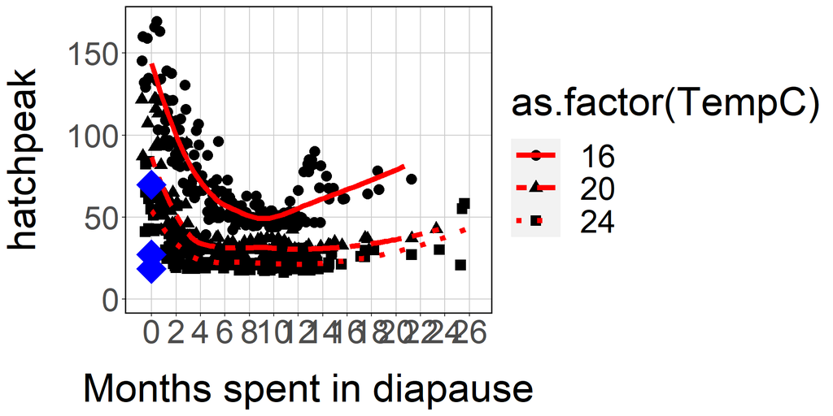

```r
treylevelplot(hatchpeak) + NDpoint
```

### 3.3.2. Hatching peak statistics

The general response of the hatching peak was affected by the the different time length spent in diapause and the different incubation temperatures.

```r
gamhp <- mgcv::gam(hatchpeak ~ s(DiapMonths) + TempCf -1,
                   data = hatchtableNoND)

anova(gamhp)
```

```
##
## Family: gaussian
## Link function: identity
##
## Formula:
## hatchpeak ~ s(DiapMonths) + TempCf - 1
##
## Parametric Terms:
##        df    F p-value
## TempCf  3 2824  <2e-16
##
## Approximate significance of smooth terms:
##                 edf Ref.df     F p-value
## s(DiapMonths) 7.699  8.545 129.7  <2e-16
```

```r
# plot(gamhp)
# mgcv::gam.check(gamhp)

multgamhp <- glht(gamhp, linfct =c('TempCf16 - TempCf20 == 0',
                                   'TempCf16 - TempCf24 == 0',
                                   'TempCf20 - TempCf24 == 0'))
summary(multgamhp)
```

```
##
##   Simultaneous Tests for General Linear Hypotheses
##
## Fit: mgcv::gam(formula = hatchpeak ~ s(DiapMonths) + TempCf - 1, data = hatchtableNoND)
##
## Linear Hypotheses:
##                          Estimate Std. Error z value Pr(>|z|)
## TempCf16 - TempCf20 == 0   34.041      1.341  25.376   <2e-16 ***
## TempCf16 - TempCf24 == 0   46.534      1.340  34.725   <2e-16 ***
## TempCf20 - TempCf24 == 0   12.493      1.321   9.457   <2e-16 ***
## ---
## Signif. codes:  0 '***' 0.001 '**' 0.01 '*' 0.05 '.' 0.1 ' ' 1
## (Adjusted p values reported -- single-step method)
```

```r
confint(multgamhp)$confint
```

```
##                     Estimate       lwr      upr
## TempCf16 - TempCf20 34.04068 30.897560 37.18380
## TempCf16 - TempCf24 46.53378 43.393891 49.67367
## TempCf20 - TempCf24 12.49310  9.397693 15.58851
## attr(,"conf.level")
## [1] 0.95
## attr(,"calpha")
## [1] 2.343089
```

The pairwise comparisons of the different length CSE categories within the corresponding incubation temperature (not between them!) for hatching peak. 1. F statistics and compact letter display format between the categories. 2. Estimate, Std. Error, t-values and p-values above for all categories comparisons.